# Risk Factor Analysis

## Outcome Variable

**Outcome Variable:** swasted

## Predictor Variables

**Intervention Variable:** birthlen

**Adjustment Set:**

unadjusted

## Stratifying Variables

The analysis was stratified on these variable(s):

- agecat
- studyid
- country

## Data Summary

| agecat | studyid | country | birthlen | swasted | n_cell | n |
| --- | --- | --- | --- | --- | --- | --- |
| Birth | ki0047075b-MAL-ED | BANGLADESH | >=50 cm | 0 | 35 | 215 |
| Birth | ki0047075b-MAL-ED | BANGLADESH | >=50 cm | 1 | 4 | 215 |
| Birth | ki0047075b-MAL-ED | BANGLADESH | <48 cm | 0 | 95 | 215 |
| Birth | ki0047075b-MAL-ED | BANGLADESH | <48 cm | 1 | 2 | 215 |
| Birth | ki0047075b-MAL-ED | BANGLADESH | [48-50) cm | 0 | 77 | 215 |
| Birth | ki0047075b-MAL-ED | BANGLADESH | [48-50) cm | 1 | 2 | 215 |
| Birth | ki0047075b-MAL-ED | BRAZIL | >=50 cm | 0 | 30 | 62 |
| Birth | ki0047075b-MAL-ED | BRAZIL | >=50 cm | 1 | 0 | 62 |
| Birth | ki0047075b-MAL-ED | BRAZIL | <48 cm | 0 | 14 | 62 |
| Birth | ki0047075b-MAL-ED | BRAZIL | <48 cm | 1 | 0 | 62 |
| Birth | ki0047075b-MAL-ED | BRAZIL | [48-50) cm | 0 | 18 | 62 |
| Birth | ki0047075b-MAL-ED | BRAZIL | [48-50) cm | 1 | 0 | 62 |
| Birth | ki0047075b-MAL-ED | INDIA | >=50 cm | 0 | 9 | 45 |
| Birth | ki0047075b-MAL-ED | INDIA | >=50 cm | 1 | 0 | 45 |
| Birth | ki0047075b-MAL-ED | INDIA | <48 cm | 0 | 18 | 45 |
| Birth | ki0047075b-MAL-ED | INDIA | <48 cm | 1 | 0 | 45 |
| Birth | ki0047075b-MAL-ED | INDIA | [48-50) cm | 0 | 18 | 45 |
| Birth | ki0047075b-MAL-ED | INDIA | [48-50) cm | 1 | 0 | 45 |
| Birth | ki0047075b-MAL-ED | NEPAL | >=50 cm | 0 | 8 | 26 |
| Birth | ki0047075b-MAL-ED | NEPAL | >=50 cm | 1 | 0 | 26 |
| Birth | ki0047075b-MAL-ED | NEPAL | <48 cm | 0 | 10 | 26 |
| Birth | ki0047075b-MAL-ED | NEPAL | <48 cm | 1 | 1 | 26 |
| Birth | ki0047075b-MAL-ED | NEPAL | [48-50) cm | 0 | 7 | 26 |
| Birth | ki0047075b-MAL-ED | NEPAL | [48-50) cm | 1 | 0 | 26 |
| Birth | ki0047075b-MAL-ED | PERU | >=50 cm | 0 | 52 | 228 |
| Birth | ki0047075b-MAL-ED | PERU | >=50 cm | 1 | 0 | 228 |
| Birth | ki0047075b-MAL-ED | PERU | <48 cm | 0 | 83 | 228 |
| Birth | ki0047075b-MAL-ED | PERU | <48 cm | 1 | 0 | 228 |
| Birth | ki0047075b-MAL-ED | PERU | [48-50) cm | 0 | 93 | 228 |
| Birth | ki0047075b-MAL-ED | PERU | [48-50) cm | 1 | 0 | 228 |

[output cut: 426 more lines]

The following strata were considered:

- agecat: 24 months, studyid: ki0047075b-MAL-ED, country: BANGLADESH
- agecat: 24 months, studyid: ki0047075b-MAL-ED, country: BRAZIL
- agecat: 24 months, studyid: ki0047075b-MAL-ED, country: INDIA
- agecat: 24 months, studyid: ki0047075b-MAL-ED, country: NEPAL
- agecat: 24 months, studyid: ki0047075b-MAL-ED, country: PERU
- agecat: 24 months, studyid: ki0047075b-MAL-ED, country: SOUTH AFRICA
- agecat: 24 months, studyid: ki0047075b-MAL-ED, country: TANZANIA, UNITED REPUBLIC OF
- agecat: 24 months, studyid: ki1000108-CMC-V-BCS-2002, country: INDIA
- agecat: 24 months, studyid: ki1000108-IRC, country: INDIA
- agecat: 24 months, studyid: ki1000109-EE, country: PAKISTAN
- agecat: 24 months, studyid: ki1017093-NIH-Birth, country: BANGLADESH
- agecat: 24 months, studyid: ki1017093b-PROVIDE, country: BANGLADESH
- agecat: 24 months, studyid: ki1017093c-NIH-Crypto, country: BANGLADESH
- agecat: 24 months, studyid: ki1101329-Keneba, country: GAMBIA
- agecat: 24 months, studyid: ki1113344-GMS-Nepal, country: NEPAL
- agecat: 24 months, studyid: ki1114097-CMIN, country: BANGLADESH
- agecat: 24 months, studyid: ki1114097-CONTENT, country: PERU
- agecat: 24 months, studyid: ki1119695-PROBIT, country: BELARUS
- agecat: 24 months, studyid: ki1126311-ZVITAMBO, country: ZIMBABWE
- agecat: 24 months, studyid: ki1135781-COHORTS, country: GUATEMALA
- agecat: 24 months, studyid: ki1135781-COHORTS, country: INDIA
- agecat: 24 months, studyid: ki1135781-COHORTS, country: PHILIPPINES
- agecat: 24 months, studyid: kiGH5241-JiVitA-3, country: BANGLADESH
- agecat: 24 months, studyid: kiGH5241-JiVitA-4, country: BANGLADESH
- agecat: 6 months, studyid: ki0047075b-MAL-ED, country: BANGLADESH
- agecat: 6 months, studyid: ki0047075b-MAL-ED, country: BRAZIL
- agecat: 6 months, studyid: ki0047075b-MAL-ED, country: INDIA
- agecat: 6 months, studyid: ki0047075b-MAL-ED, country: NEPAL
- agecat: 6 months, studyid: ki0047075b-MAL-ED, country: PERU
- agecat: 6 months, studyid: ki0047075b-MAL-ED, country: SOUTH AFRICA
- agecat: 6 months, studyid: ki0047075b-MAL-ED, country: TANZANIA, UNITED REPUBLIC OF
- agecat: 6 months, studyid: ki1000108-CMC-V-BCS-2002, country: INDIA
- agecat: 6 months, studyid: ki1000108-IRC, country: INDIA
- agecat: 6 months, studyid: ki1000109-EE, country: PAKISTAN
- agecat: 6 months, studyid: ki1000109-ResPak, country: PAKISTAN
- agecat: 6 months, studyid: ki1000304b-SAS-CompFeed, country: INDIA
- agecat: 6 months, studyid: ki1017093-NIH-Birth, country: BANGLADESH
- agecat: 6 months, studyid: ki1017093b-PROVIDE, country: BANGLADESH
- agecat: 6 months, studyid: ki1017093c-NIH-Crypto, country: BANGLADESH
- agecat: 6 months, studyid: ki1101329-Keneba, country: GAMBIA
- agecat: 6 months, studyid: ki1113344-GMS-Nepal, country: NEPAL
- agecat: 6 months, studyid: ki1114097-CMIN, country: BANGLADESH
- agecat: 6 months, studyid: ki1114097-CONTENT, country: PERU
- agecat: 6 months, studyid: ki1119695-PROBIT, country: BELARUS
- agecat: 6 months, studyid: ki1126311-ZVITAMBO, country: ZIMBABWE
- agecat: 6 months, studyid: ki1135781-COHORTS, country: GUATEMALA
- agecat: 6 months, studyid: ki1135781-COHORTS, country: INDIA
- agecat: 6 months, studyid: ki1135781-COHORTS, country: PHILIPPINES
- agecat: 6 months, studyid: kiGH5241-JiVitA-3, country: BANGLADESH
- agecat: 6 months, studyid: kiGH5241-JiVitA-4, country: BANGLADESH
- agecat: Birth, studyid: ki0047075b-MAL-ED, country: BANGLADESH
- agecat: Birth, studyid: ki0047075b-MAL-ED, country: BRAZIL
- agecat: Birth, studyid: ki0047075b-MAL-ED, country: INDIA
- agecat: Birth, studyid: ki0047075b-MAL-ED, country: NEPAL
- agecat: Birth, studyid: ki0047075b-MAL-ED, country: PERU
- agecat: Birth, studyid: ki0047075b-MAL-ED, country: SOUTH AFRICA
- agecat: Birth, studyid: ki0047075b-MAL-ED, country: TANZANIA, UNITED REPUBLIC OF
- agecat: Birth, studyid: ki1000108-CMC-V-BCS-2002, country: INDIA
- agecat: Birth, studyid: ki1000108-IRC, country: INDIA
- agecat: Birth, studyid: ki1000109-EE, country: PAKISTAN
- agecat: Birth, studyid: ki1000109-ResPak, country: PAKISTAN
- agecat: Birth, studyid: ki1000304b-SAS-CompFeed, country: INDIA
- agecat: Birth, studyid: ki1017093-NIH-Birth, country: BANGLADESH
- agecat: Birth, studyid: ki1017093b-PROVIDE, country: BANGLADESH
- agecat: Birth, studyid: ki1017093c-NIH-Crypto, country: BANGLADESH
- agecat: Birth, studyid: ki1101329-Keneba, country: GAMBIA
- agecat: Birth, studyid: ki1113344-GMS-Nepal, country: NEPAL
- agecat: Birth, studyid: ki1114097-CMIN, country: BANGLADESH
- agecat: Birth, studyid: ki1114097-CONTENT, country: PERU
- agecat: Birth, studyid: ki1119695-PROBIT, country: BELARUS
- agecat: Birth, studyid: ki1126311-ZVITAMBO, country: ZIMBABWE
- agecat: Birth, studyid: ki1135781-COHORTS, country: GUATEMALA
- agecat: Birth, studyid: ki1135781-COHORTS, country: INDIA
- agecat: Birth, studyid: ki1135781-COHORTS, country: PHILIPPINES
- agecat: Birth, studyid: kiGH5241-JiVitA-3, country: BANGLADESH
- agecat: Birth, studyid: kiGH5241-JiVitA-4, country: BANGLADESH

### Dropped Strata

Some strata were dropped due to rare outcomes:

- agecat: Birth, studyid: ki0047075b-MAL-ED, country: BANGLADESH
- agecat: Birth, studyid: ki0047075b-MAL-ED, country: BRAZIL
- agecat: Birth, studyid: ki0047075b-MAL-ED, country: INDIA
- agecat: Birth, studyid: ki0047075b-MAL-ED, country: NEPAL
- agecat: Birth, studyid: ki0047075b-MAL-ED, country: PERU
- agecat: Birth, studyid: ki0047075b-MAL-ED, country: SOUTH AFRICA
- agecat: Birth, studyid: ki0047075b-MAL-ED, country: TANZANIA, UNITED REPUBLIC OF
- agecat: Birth, studyid: ki1000108-CMC-V-BCS-2002, country: INDIA
- agecat: Birth, studyid: ki1000109-EE, country: PAKISTAN
- agecat: Birth, studyid: ki1000109-ResPak, country: PAKISTAN
- agecat: Birth, studyid: ki1000304b-SAS-CompFeed, country: INDIA
- agecat: Birth, studyid: ki1017093b-PROVIDE, country: BANGLADESH
- agecat: Birth, studyid: ki1114097-CMIN, country: BANGLADESH
- agecat: Birth, studyid: ki1114097-CONTENT, country: PERU
- agecat: Birth, studyid: ki1119695-PROBIT, country: BELARUS
- agecat: Birth, studyid: ki1135781-COHORTS, country: GUATEMALA
- agecat: Birth, studyid: kiGH5241-JiVitA-4, country: BANGLADESH
- agecat: 6 months, studyid: ki0047075b-MAL-ED, country: BANGLADESH
- agecat: 6 months, studyid: ki0047075b-MAL-ED, country: BRAZIL
- agecat: 6 months, studyid: ki0047075b-MAL-ED, country: INDIA
- agecat: 6 months, studyid: ki0047075b-MAL-ED, country: NEPAL
- agecat: 6 months, studyid: ki0047075b-MAL-ED, country: PERU
- agecat: 6 months, studyid: ki0047075b-MAL-ED, country: SOUTH AFRICA
- agecat: 6 months, studyid: ki0047075b-MAL-ED, country: TANZANIA, UNITED REPUBLIC OF
- agecat: 6 months, studyid: ki1000108-CMC-V-BCS-2002, country: INDIA
- agecat: 6 months, studyid: ki1000108-IRC, country: INDIA
- agecat: 6 months, studyid: ki1000109-EE, country: PAKISTAN
- agecat: 6 months, studyid: ki1000109-ResPak, country: PAKISTAN
- agecat: 6 months, studyid: ki1000304b-SAS-CompFeed, country: INDIA
- agecat: 6 months, studyid: ki1017093-NIH-Birth, country: BANGLADESH
- agecat: 6 months, studyid: ki1017093b-PROVIDE, country: BANGLADESH
- agecat: 6 months, studyid: ki1017093c-NIH-Crypto, country: BANGLADESH
- agecat: 6 months, studyid: ki1101329-Keneba, country: GAMBIA
- agecat: 6 months, studyid: ki1113344-GMS-Nepal, country: NEPAL
- agecat: 6 months, studyid: ki1114097-CMIN, country: BANGLADESH
- agecat: 6 months, studyid: ki1114097-CONTENT, country: PERU
- agecat: 6 months, studyid: ki1119695-PROBIT, country: BELARUS
- agecat: 6 months, studyid: ki1135781-COHORTS, country: GUATEMALA
- agecat: 6 months, studyid: kiGH5241-JiVitA-4, country: BANGLADESH
- agecat: 24 months, studyid: ki0047075b-MAL-ED, country: BANGLADESH
- agecat: 24 months, studyid: ki0047075b-MAL-ED, country: BRAZIL
- agecat: 24 months, studyid: ki0047075b-MAL-ED, country: INDIA
- agecat: 24 months, studyid: ki0047075b-MAL-ED, country: NEPAL
- agecat: 24 months, studyid: ki0047075b-MAL-ED, country: PERU
- agecat: 24 months, studyid: ki0047075b-MAL-ED, country: SOUTH AFRICA
- agecat: 24 months, studyid: ki0047075b-MAL-ED, country: TANZANIA, UNITED REPUBLIC OF
- agecat: 24 months, studyid: ki1000108-CMC-V-BCS-2002, country: INDIA
- agecat: 24 months, studyid: ki1000108-IRC, country: INDIA
- agecat: 24 months, studyid: ki1000109-EE, country: PAKISTAN
- agecat: 24 months, studyid: ki1017093-NIH-Birth, country: BANGLADESH
- agecat: 24 months, studyid: ki1017093b-PROVIDE, country: BANGLADESH
- agecat: 24 months, studyid: ki1017093c-NIH-Crypto, country: BANGLADESH
- agecat: 24 months, studyid: ki1113344-GMS-Nepal, country: NEPAL
- agecat: 24 months, studyid: ki1114097-CMIN, country: BANGLADESH
- agecat: 24 months, studyid: ki1114097-CONTENT, country: PERU
- agecat: 24 months, studyid: ki1119695-PROBIT, country: BELARUS
- agecat: 24 months, studyid: ki1126311-ZVITAMBO, country: ZIMBABWE
- agecat: 24 months, studyid: ki1135781-COHORTS, country: GUATEMALA
- agecat: 24 months, studyid: ki1135781-COHORTS, country: PHILIPPINES

## Methods Detail

We’re interested in the causal parameters $E[Y_a]$ for all values of $a \in \mathcal{A}$. These parameters represent the mean outcome if, possibly contrary to fact, we intervened to set all units to have $A=a$. Under the randomization and positivity assumptions, these are identified by the statistical parameters $\psi_a=E_W[E_{Y|A,W}(Y|A=a,W)]$. In addition, we’re interested in the mean of $Y$, $E[Y]$ under no intervention (the observed mean). We will estimate these parameters by using SuperLearner to fit the relevant likelihood factors – $E_{Y|A,W}(Y|A=a,W)$ and $p(A=a|W)$, and then updating our likelihood fit using a joint TMLE.

For unadjusted analyses ($W=\{\}$), initial likelihoods were estimated using Lrnr_glm to estimate the simple $E(Y|A)$ and Lrnr_mean to estimate $p(A)$. For adjusted analyses, a small library containing Lrnr_glmnet, Lrnr_xgboost, and Lrnr_mean was used.

Having estimated these parameters, we will then use the delta method to estimate relative risks and attributable risks relative to a prespecified baseline level of $A$.

# Results Detail

## Results Plots

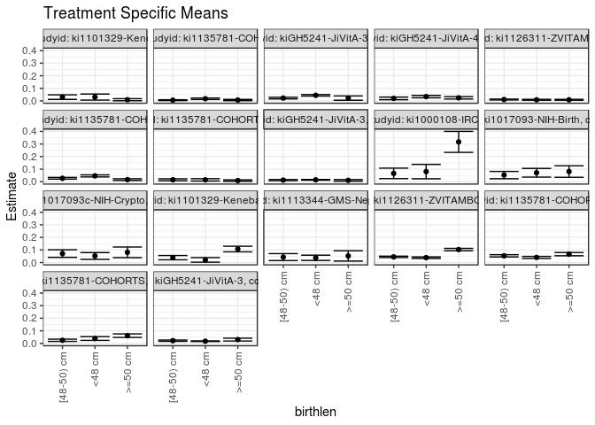

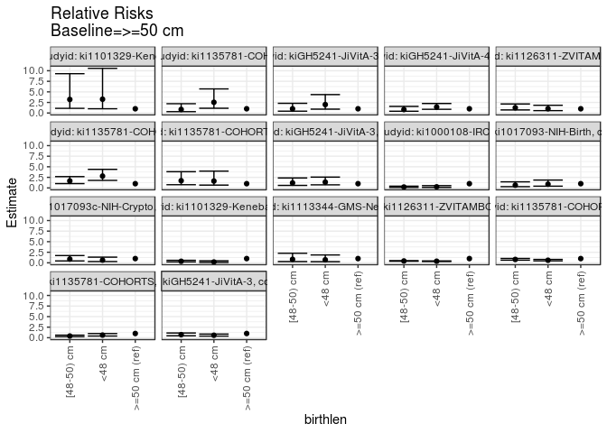

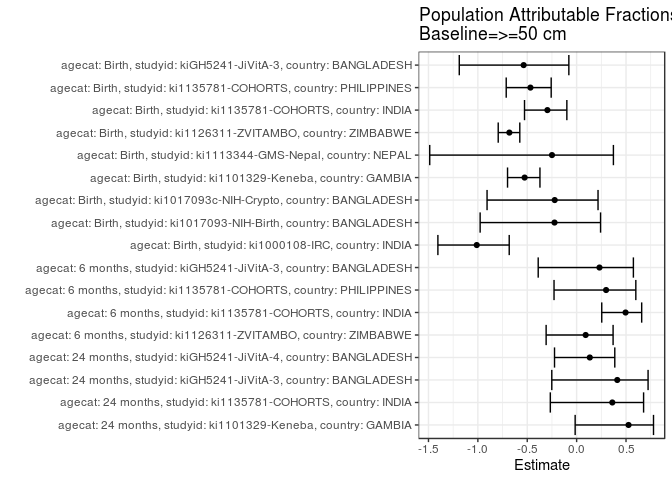

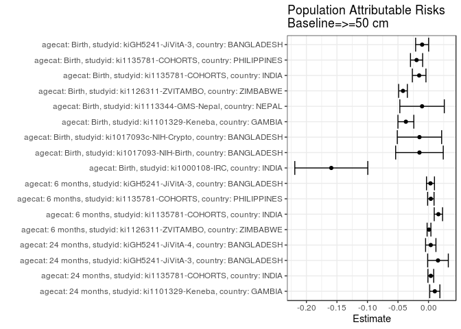

## Results Table

### Parameter: TSM

| agecat | studyid | country | intervention_level | baseline_level | estimate | ci_lower | ci_upper |
| --- | --- | --- | --- | --- | --- | --- | --- |
| Birth | ki1000108-IRC | INDIA | >=50 cm | NA | 0.3166667 | 0.2333160 | 0.4000173 |
| Birth | ki1000108-IRC | INDIA | <48 cm | NA | 0.0804598 | 0.0232201 | 0.1376995 |
| Birth | ki1000108-IRC | INDIA | [48-50) cm | NA | 0.0661765 | 0.0243360 | 0.1080170 |
| Birth | ki1017093-NIH-Birth | BANGLADESH | >=50 cm | NA | 0.0808824 | 0.0350187 | 0.1267460 |
| Birth | ki1017093-NIH-Birth | BANGLADESH | <48 cm | NA | 0.0710900 | 0.0363863 | 0.1057938 |
| Birth | ki1017093-NIH-Birth | BANGLADESH | [48-50) cm | NA | 0.0526316 | 0.0236220 | 0.0816411 |
| Birth | ki1017093c-NIH-Crypto | BANGLADESH | >=50 cm | NA | 0.0812500 | 0.0388851 | 0.1236149 |
| Birth | ki1017093c-NIH-Crypto | BANGLADESH | <48 cm | NA | 0.0524345 | 0.0256790 | 0.0791899 |
| Birth | ki1017093c-NIH-Crypto | BANGLADESH | [48-50) cm | NA | 0.0714286 | 0.0412416 | 0.1016156 |
| Birth | ki1101329-Keneba | GAMBIA | >=50 cm | NA | 0.1073370 | 0.0849664 | 0.1297075 |
| Birth | ki1101329-Keneba | GAMBIA | <48 cm | NA | 0.0208333 | 0.0027575 | 0.0389092 |
| Birth | ki1101329-Keneba | GAMBIA | [48-50) cm | NA | 0.0388548 | 0.0217208 | 0.0559888 |
| Birth | ki1113344-GMS-Nepal | NEPAL | >=50 cm | NA | 0.0526316 | 0.0116095 | 0.0936536 |
| Birth | ki1113344-GMS-Nepal | NEPAL | <48 cm | NA | 0.0376176 | 0.0167217 | 0.0585134 |
| Birth | ki1113344-GMS-Nepal | NEPAL | [48-50) cm | NA | 0.0432692 | 0.0155973 | 0.0709412 |
| Birth | ki1126311-ZVITAMBO | ZIMBABWE | >=50 cm | NA | 0.1030773 | 0.0936507 | 0.1125039 |
| Birth | ki1126311-ZVITAMBO | ZIMBABWE | <48 cm | NA | 0.0390003 | 0.0327117 | 0.0452888 |
| Birth | ki1126311-ZVITAMBO | ZIMBABWE | [48-50) cm | NA | 0.0450843 | 0.0394869 | 0.0506817 |
| Birth | ki1135781-COHORTS | INDIA | >=50 cm | NA | 0.0669516 | 0.0538769 | 0.0800263 |
| Birth | ki1135781-COHORTS | INDIA | <48 cm | NA | 0.0407817 | 0.0327912 | 0.0487721 |
| Birth | ki1135781-COHORTS | INDIA | [48-50) cm | NA | 0.0533881 | 0.0444583 | 0.0623179 |
| Birth | ki1135781-COHORTS | PHILIPPINES | >=50 cm | NA | 0.0612613 | 0.0471513 | 0.0753713 |
| Birth | ki1135781-COHORTS | PHILIPPINES | <48 cm | NA | 0.0384025 | 0.0236383 | 0.0531666 |
| Birth | ki1135781-COHORTS | PHILIPPINES | [48-50) cm | NA | 0.0246046 | 0.0156023 | 0.0336068 |
| Birth | kiGH5241-JiVitA-3 | BANGLADESH | >=50 cm | NA | 0.0297667 | 0.0184927 | 0.0410407 |
| Birth | kiGH5241-JiVitA-3 | BANGLADESH | <48 cm | NA | 0.0173623 | 0.0147999 | 0.0199247 |
| Birth | kiGH5241-JiVitA-3 | BANGLADESH | [48-50) cm | NA | 0.0214609 | 0.0163746 | 0.0265473 |
| 6 months | ki1126311-ZVITAMBO | ZIMBABWE | >=50 cm | NA | 0.0085331 | 0.0048989 | 0.0121673 |
| 6 months | ki1126311-ZVITAMBO | ZIMBABWE | <48 cm | NA | 0.0086564 | 0.0051338 | 0.0121789 |
| 6 months | ki1126311-ZVITAMBO | ZIMBABWE | [48-50) cm | NA | 0.0106222 | 0.0071216 | 0.0141227 |
| 6 months | ki1135781-COHORTS | INDIA | >=50 cm | NA | 0.0165538 | 0.0096935 | 0.0234141 |
| 6 months | ki1135781-COHORTS | INDIA | <48 cm | NA | 0.0463000 | 0.0381063 | 0.0544936 |
| 6 months | ki1135781-COHORTS | INDIA | [48-50) cm | NA | 0.0273007 | 0.0205980 | 0.0340035 |
| 6 months | ki1135781-COHORTS | PHILIPPINES | >=50 cm | NA | 0.0091001 | 0.0031808 | 0.0150194 |
| 6 months | ki1135781-COHORTS | PHILIPPINES | <48 cm | NA | 0.0147710 | 0.0056822 | 0.0238599 |
| 6 months | ki1135781-COHORTS | PHILIPPINES | [48-50) cm | NA | 0.0154889 | 0.0079571 | 0.0230207 |
| 6 months | kiGH5241-JiVitA-3 | BANGLADESH | >=50 cm | NA | 0.0108959 | 0.0044253 | 0.0173665 |
| 6 months | kiGH5241-JiVitA-3 | BANGLADESH | <48 cm | NA | 0.0148888 | 0.0120858 | 0.0176919 |
| 6 months | kiGH5241-JiVitA-3 | BANGLADESH | [48-50) cm | NA | 0.0128558 | 0.0085196 | 0.0171921 |
| 24 months | ki1101329-Keneba | GAMBIA | >=50 cm | NA | 0.0093458 | 0.0011885 | 0.0175031 |
| 24 months | ki1101329-Keneba | GAMBIA | <48 cm | NA | 0.0304569 | 0.0064495 | 0.0544642 |
| 24 months | ki1101329-Keneba | GAMBIA | [48-50) cm | NA | 0.0299401 | 0.0116547 | 0.0482255 |
| 24 months | ki1135781-COHORTS | INDIA | >=50 cm | NA | 0.0067633 | 0.0017695 | 0.0117571 |
| 24 months | ki1135781-COHORTS | INDIA | <48 cm | NA | 0.0171162 | 0.0113260 | 0.0229064 |
| 24 months | ki1135781-COHORTS | INDIA | [48-50) cm | NA | 0.0056850 | 0.0021711 | 0.0091990 |
| 24 months | kiGH5241-JiVitA-3 | BANGLADESH | >=50 cm | NA | 0.0222772 | 0.0052361 | 0.0393183 |
| 24 months | kiGH5241-JiVitA-3 | BANGLADESH | <48 cm | NA | 0.0443564 | 0.0382215 | 0.0504914 |
| 24 months | kiGH5241-JiVitA-3 | BANGLADESH | [48-50) cm | NA | 0.0222874 | 0.0156040 | 0.0289708 |
| 24 months | kiGH5241-JiVitA-4 | BANGLADESH | >=50 cm | NA | 0.0242086 | 0.0149088 | 0.0335084 |
| 24 months | kiGH5241-JiVitA-4 | BANGLADESH | <48 cm | NA | 0.0340733 | 0.0244481 | 0.0436985 |
| 24 months | kiGH5241-JiVitA-4 | BANGLADESH | [48-50) cm | NA | 0.0197300 | 0.0093757 | 0.0300844 |

### Parameter: E(Y)

| agecat | studyid | country | intervention_level | baseline_level | estimate | ci_lower | ci_upper |
| --- | --- | --- | --- | --- | --- | --- | --- |
| Birth | ki1000108-IRC | INDIA | NA | NA | 0.1574344 | 0.1188345 | 0.1960344 |
| Birth | ki1017093-NIH-Birth | BANGLADESH | NA | NA | 0.0660870 | 0.0457632 | 0.0864107 |
| Birth | ki1017093c-NIH-Crypto | BANGLADESH | NA | NA | 0.0664781 | 0.0481022 | 0.0848539 |
| Birth | ki1101329-Keneba | GAMBIA | NA | NA | 0.0703072 | 0.0572109 | 0.0834034 |
| Birth | ki1113344-GMS-Nepal | NEPAL | NA | NA | 0.0421217 | 0.0265597 | 0.0576837 |
| Birth | ki1126311-ZVITAMBO | ZIMBABWE | NA | NA | 0.0613145 | 0.0571772 | 0.0654519 |
| Birth | ki1135781-COHORTS | INDIA | NA | NA | 0.0516712 | 0.0461576 | 0.0571849 |
| Birth | ki1135781-COHORTS | PHILIPPINES | NA | NA | 0.0417385 | 0.0344572 | 0.0490198 |
| Birth | kiGH5241-JiVitA-3 | BANGLADESH | NA | NA | 0.0193738 | 0.0169653 | 0.0217823 |
| 6 months | ki1126311-ZVITAMBO | ZIMBABWE | NA | NA | 0.0093902 | 0.0073292 | 0.0114513 |
| 6 months | ki1135781-COHORTS | INDIA | NA | NA | 0.0328056 | 0.0283450 | 0.0372662 |
| 6 months | ki1135781-COHORTS | PHILIPPINES | NA | NA | 0.0129678 | 0.0086988 | 0.0172368 |
| 6 months | kiGH5241-JiVitA-3 | BANGLADESH | NA | NA | 0.0141737 | 0.0119136 | 0.0164337 |
| 24 months | ki1101329-Keneba | GAMBIA | NA | NA | 0.0196998 | 0.0113537 | 0.0280459 |
| 24 months | ki1135781-COHORTS | INDIA | NA | NA | 0.0105887 | 0.0076690 | 0.0135085 |
| 24 months | kiGH5241-JiVitA-3 | BANGLADESH | NA | NA | 0.0378544 | 0.0331920 | 0.0425169 |
| 24 months | kiGH5241-JiVitA-4 | BANGLADESH | NA | NA | 0.0279316 | 0.0220494 | 0.0338137 |

### Parameter: RR

| agecat | studyid | country | intervention_level | baseline_level | estimate | ci_lower | ci_upper |
| --- | --- | --- | --- | --- | --- | --- | --- |
| Birth | ki1000108-IRC | INDIA | >=50 cm | >=50 cm | 1.0000000 | 1.0000000 | 1.0000000 |
| Birth | ki1000108-IRC | INDIA | <48 cm | >=50 cm | 0.2540835 | 0.1190000 | 0.5425075 |
| Birth | ki1000108-IRC | INDIA | [48-50) cm | >=50 cm | 0.2089783 | 0.1053590 | 0.4145060 |
| Birth | ki1017093-NIH-Birth | BANGLADESH | >=50 cm | >=50 cm | 1.0000000 | 1.0000000 | 1.0000000 |
| Birth | ki1017093-NIH-Birth | BANGLADESH | <48 cm | >=50 cm | 0.8789315 | 0.4159149 | 1.8574004 |
| Birth | ki1017093-NIH-Birth | BANGLADESH | [48-50) cm | >=50 cm | 0.6507177 | 0.2950936 | 1.4349125 |
| Birth | ki1017093c-NIH-Crypto | BANGLADESH | >=50 cm | >=50 cm | 1.0000000 | 1.0000000 | 1.0000000 |
| Birth | ki1017093c-NIH-Crypto | BANGLADESH | <48 cm | >=50 cm | 0.6453472 | 0.3111386 | 1.3385447 |
| Birth | ki1017093c-NIH-Crypto | BANGLADESH | [48-50) cm | >=50 cm | 0.8791209 | 0.4493246 | 1.7200338 |
| Birth | ki1101329-Keneba | GAMBIA | >=50 cm | >=50 cm | 1.0000000 | 1.0000000 | 1.0000000 |
| Birth | ki1101329-Keneba | GAMBIA | <48 cm | >=50 cm | 0.1940928 | 0.0795206 | 0.4737392 |
| Birth | ki1101329-Keneba | GAMBIA | [48-50) cm | >=50 cm | 0.3619891 | 0.2222647 | 0.5895498 |
| Birth | ki1113344-GMS-Nepal | NEPAL | >=50 cm | >=50 cm | 1.0000000 | 1.0000000 | 1.0000000 |
| Birth | ki1113344-GMS-Nepal | NEPAL | <48 cm | >=50 cm | 0.7147335 | 0.2744591 | 1.8612754 |
| Birth | ki1113344-GMS-Nepal | NEPAL | [48-50) cm | >=50 cm | 0.8221154 | 0.2999658 | 2.2531693 |
| Birth | ki1126311-ZVITAMBO | ZIMBABWE | >=50 cm | >=50 cm | 1.0000000 | 1.0000000 | 1.0000000 |
| Birth | ki1126311-ZVITAMBO | ZIMBABWE | <48 cm | >=50 cm | 0.3783595 | 0.3143390 | 0.4554187 |
| Birth | ki1126311-ZVITAMBO | ZIMBABWE | [48-50) cm | >=50 cm | 0.4373833 | 0.3748816 | 0.5103056 |
| Birth | ki1135781-COHORTS | INDIA | >=50 cm | >=50 cm | 1.0000000 | 1.0000000 | 1.0000000 |
| Birth | ki1135781-COHORTS | INDIA | <48 cm | >=50 cm | 0.6091217 | 0.4619167 | 0.8032385 |
| Birth | ki1135781-COHORTS | INDIA | [48-50) cm | >=50 cm | 0.7974136 | 0.6166173 | 1.0312207 |
| Birth | ki1135781-COHORTS | PHILIPPINES | >=50 cm | >=50 cm | 1.0000000 | 1.0000000 | 1.0000000 |
| Birth | ki1135781-COHORTS | PHILIPPINES | <48 cm | >=50 cm | 0.6268636 | 0.4004373 | 0.9813223 |
| Birth | ki1135781-COHORTS | PHILIPPINES | [48-50) cm | >=50 cm | 0.4016334 | 0.2606564 | 0.6188584 |
| Birth | kiGH5241-JiVitA-3 | BANGLADESH | >=50 cm | >=50 cm | 1.0000000 | 1.0000000 | 1.0000000 |
| Birth | kiGH5241-JiVitA-3 | BANGLADESH | <48 cm | >=50 cm | 0.5832794 | 0.3894857 | 0.8734977 |
| Birth | kiGH5241-JiVitA-3 | BANGLADESH | [48-50) cm | >=50 cm | 0.7209708 | 0.4645796 | 1.1188587 |
| 6 months | ki1126311-ZVITAMBO | ZIMBABWE | >=50 cm | >=50 cm | 1.0000000 | 1.0000000 | 1.0000000 |
| 6 months | ki1126311-ZVITAMBO | ZIMBABWE | <48 cm | >=50 cm | 1.0144452 | 0.5628686 | 1.8283115 |
| 6 months | ki1126311-ZVITAMBO | ZIMBABWE | [48-50) cm | >=50 cm | 1.2448154 | 0.7264975 | 2.1329258 |
| 6 months | ki1135781-COHORTS | INDIA | >=50 cm | >=50 cm | 1.0000000 | 1.0000000 | 1.0000000 |
| 6 months | ki1135781-COHORTS | INDIA | <48 cm | >=50 cm | 2.7969383 | 1.7822838 | 4.3892357 |
| 6 months | ki1135781-COHORTS | INDIA | [48-50) cm | >=50 cm | 1.6492132 | 1.0187811 | 2.6697631 |
| 6 months | ki1135781-COHORTS | PHILIPPINES | >=50 cm | >=50 cm | 1.0000000 | 1.0000000 | 1.0000000 |
| 6 months | ki1135781-COHORTS | PHILIPPINES | <48 cm | >=50 cm | 1.6231741 | 0.6629864 | 3.9739795 |
| 6 months | ki1135781-COHORTS | PHILIPPINES | [48-50) cm | >=50 cm | 1.7020544 | 0.7555587 | 3.8342347 |
| 6 months | kiGH5241-JiVitA-3 | BANGLADESH | >=50 cm | >=50 cm | 1.0000000 | 1.0000000 | 1.0000000 |
| 6 months | kiGH5241-JiVitA-3 | BANGLADESH | <48 cm | >=50 cm | 1.3664650 | 0.7314499 | 2.5527743 |
| 6 months | kiGH5241-JiVitA-3 | BANGLADESH | [48-50) cm | >=50 cm | 1.1798796 | 0.5910502 | 2.3553259 |
| 24 months | ki1101329-Keneba | GAMBIA | >=50 cm | >=50 cm | 1.0000000 | 1.0000000 | 1.0000000 |
| 24 months | ki1101329-Keneba | GAMBIA | <48 cm | >=50 cm | 3.2588832 | 1.0053237 | 10.5640797 |
| 24 months | ki1101329-Keneba | GAMBIA | [48-50) cm | >=50 cm | 3.2035928 | 1.1040590 | 9.2957052 |
| 24 months | ki1135781-COHORTS | INDIA | >=50 cm | >=50 cm | 1.0000000 | 1.0000000 | 1.0000000 |
| 24 months | ki1135781-COHORTS | INDIA | <48 cm | >=50 cm | 2.5307499 | 1.1233819 | 5.7012625 |
| 24 months | ki1135781-COHORTS | INDIA | [48-50) cm | >=50 cm | 0.8405750 | 0.3209098 | 2.2017599 |
| 24 months | kiGH5241-JiVitA-3 | BANGLADESH | >=50 cm | >=50 cm | 1.0000000 | 1.0000000 | 1.0000000 |
| 24 months | kiGH5241-JiVitA-3 | BANGLADESH | <48 cm | >=50 cm | 1.9911111 | 0.9107336 | 4.3531099 |
| 24 months | kiGH5241-JiVitA-3 | BANGLADESH | [48-50) cm | >=50 cm | 1.0004562 | 0.4365029 | 2.2930260 |
| 24 months | kiGH5241-JiVitA-4 | BANGLADESH | >=50 cm | >=50 cm | 1.0000000 | 1.0000000 | 1.0000000 |
| 24 months | kiGH5241-JiVitA-4 | BANGLADESH | <48 cm | >=50 cm | 1.4074898 | 0.8801676 | 2.2507389 |
| 24 months | kiGH5241-JiVitA-4 | BANGLADESH | [48-50) cm | >=50 cm | 0.8150012 | 0.4238540 | 1.5671126 |

### Parameter: PAR

| agecat | studyid | country | intervention_level | baseline_level | estimate | ci_lower | ci_upper |
| --- | --- | --- | --- | --- | --- | --- | --- |
| Birth | ki1000108-IRC | INDIA | >=50 cm | NA | -0.1592323 | -0.2190334 | -0.0994311 |
| Birth | ki1017093-NIH-Birth | BANGLADESH | >=50 cm | NA | -0.0147954 | -0.0538017 | 0.0242110 |
| Birth | ki1017093c-NIH-Crypto | BANGLADESH | >=50 cm | NA | -0.0147719 | -0.0511052 | 0.0215613 |
| Birth | ki1101329-Keneba | GAMBIA | >=50 cm | NA | -0.0370298 | -0.0500344 | -0.0240251 |
| Birth | ki1113344-GMS-Nepal | NEPAL | >=50 cm | NA | -0.0105099 | -0.0469299 | 0.0259102 |
| Birth | ki1126311-ZVITAMBO | ZIMBABWE | >=50 cm | NA | -0.0417628 | -0.0489032 | -0.0346224 |
| Birth | ki1135781-COHORTS | INDIA | >=50 cm | NA | -0.0152803 | -0.0264086 | -0.0041521 |
| Birth | ki1135781-COHORTS | PHILIPPINES | >=50 cm | NA | -0.0195227 | -0.0295051 | -0.0095403 |
| Birth | kiGH5241-JiVitA-3 | BANGLADESH | >=50 cm | NA | -0.0103929 | -0.0210403 | 0.0002545 |
| 6 months | ki1126311-ZVITAMBO | ZIMBABWE | >=50 cm | NA | 0.0008571 | -0.0022619 | 0.0039762 |
| 6 months | ki1135781-COHORTS | INDIA | >=50 cm | NA | 0.0162518 | 0.0094295 | 0.0230741 |
| 6 months | ki1135781-COHORTS | PHILIPPINES | >=50 cm | NA | 0.0038677 | -0.0013844 | 0.0091197 |
| 6 months | kiGH5241-JiVitA-3 | BANGLADESH | >=50 cm | NA | 0.0032778 | -0.0032527 | 0.0098083 |
| 24 months | ki1101329-Keneba | GAMBIA | >=50 cm | NA | 0.0103540 | 0.0020229 | 0.0186852 |
| 24 months | ki1135781-COHORTS | INDIA | >=50 cm | NA | 0.0038254 | -0.0009212 | 0.0085721 |
| 24 months | kiGH5241-JiVitA-3 | BANGLADESH | >=50 cm | NA | 0.0155772 | -0.0013349 | 0.0324894 |
| 24 months | kiGH5241-JiVitA-4 | BANGLADESH | >=50 cm | NA | 0.0037230 | -0.0047529 | 0.0121989 |

### Parameter: PAF

| agecat | studyid | country | intervention_level | baseline_level | estimate | ci_lower | ci_upper |
| --- | --- | --- | --- | --- | --- | --- | --- |
| Birth | ki1000108-IRC | INDIA | >=50 cm | NA | -1.0114198 | -1.4046724 | -0.6824784 |
| Birth | ki1017093-NIH-Birth | BANGLADESH | >=50 cm | NA | -0.2238777 | -0.9769677 | 0.2423363 |
| Birth | ki1017093c-NIH-Crypto | BANGLADESH | >=50 cm | NA | -0.2222074 | -0.9069376 | 0.2166545 |
| Birth | ki1101329-Keneba | GAMBIA | >=50 cm | NA | -0.5266858 | -0.6995299 | -0.3714202 |
| Birth | ki1113344-GMS-Nepal | NEPAL | >=50 cm | NA | -0.2495127 | -1.4873677 | 0.3723156 |
| Birth | ki1126311-ZVITAMBO | ZIMBABWE | >=50 cm | NA | -0.6811232 | -0.7938928 | -0.5754427 |
| Birth | ki1135781-COHORTS | INDIA | >=50 cm | NA | -0.2957220 | -0.5276673 | -0.0989929 |
| Birth | ki1135781-COHORTS | PHILIPPINES | >=50 cm | NA | -0.4677388 | -0.7128845 | -0.2576780 |
| Birth | kiGH5241-JiVitA-3 | BANGLADESH | >=50 cm | NA | -0.5364390 | -1.1881488 | -0.0788319 |
| 6 months | ki1126311-ZVITAMBO | ZIMBABWE | >=50 cm | NA | 0.0912771 | -0.3088554 | 0.3690844 |
| 6 months | ki1135781-COHORTS | INDIA | >=50 cm | NA | 0.4953973 | 0.2541956 | 0.6585916 |
| 6 months | ki1135781-COHORTS | PHILIPPINES | >=50 cm | NA | 0.2982522 | -0.2288368 | 0.5992552 |
| 6 months | kiGH5241-JiVitA-3 | BANGLADESH | >=50 cm | NA | 0.2312594 | -0.3890986 | 0.5745716 |
| 24 months | ki1101329-Keneba | GAMBIA | >=50 cm | NA | 0.5255897 | -0.0150497 | 0.7782718 |
| 24 months | ki1135781-COHORTS | INDIA | >=50 cm | NA | 0.3612754 | -0.2664726 | 0.6778697 |
| 24 months | kiGH5241-JiVitA-3 | BANGLADESH | >=50 cm | NA | 0.4115030 | -0.2515399 | 0.7232780 |
| 24 months | kiGH5241-JiVitA-4 | BANGLADESH | >=50 cm | NA | 0.1332897 | -0.2239084 | 0.3862394 |